# ECOM5001_Project_20797133

```python
import pandas as pd
from datetime import datetime
from datetime import date
from scipy.stats import linregress
```

Import New York Stock Exchange Index's historical data

```python
nyse_df = pd.read_csv("NYA.csv")
```

```python
print(nyse_df)
```

```
            Date          Open          High           Low         Close  \
0     2015-10-22  10342.750000  10467.110352  10342.750000  10448.830078
1     2015-10-23  10486.940430  10519.830078  10450.440430  10506.509766
2     2015-10-26  10495.910156  10495.910156  10458.059570  10464.620117
3     2015-10-27  10420.750000  10427.750000  10364.919922  10400.179688
4     2015-10-28  10428.030273  10538.219727  10409.459961  10538.200195
...          ...           ...           ...           ...           ...
1863  2023-03-20  14599.049805  14817.209961  14599.049805  14777.700195
1864  2023-03-21  14777.700195  15010.580078  14777.700195  14985.950195
1865  2023-03-22  14985.950195  15076.129883  14740.190430  14741.080078
1866  2023-03-23  14741.080078  14937.900391  14598.320313  14693.019531
1867  2023-03-24  14693.019531  14770.790039  14514.570313  14758.570313

         Adj Close      Volume
0     10448.830078  4430850000
1     10506.509766  4108460000
2     10464.620117  3385800000
3     10400.179688  4216880000
4     10538.200195  4698110000
...            ...         ...
1863  14777.700195  5347140000
1864  14985.950195  4920240000
1865  14741.080078  4533010000
1866  14693.019531  4991600000
1867  14758.570313  4583970000

[1868 rows x 7 columns]
```

Import Ferrrari's historical stock price data

```python
ferrari_stock_df = pd.read_csv("RACE.csv")
```

```python
print(ferrari_stock_df)
```

```
            Date        Open        High         Low       Close   Adj Close  \
0     2015-10-22   57.070000   58.200001   55.700001   56.750000   53.604130
1     2015-10-23   57.770000   58.000000   56.270000   56.380001   53.254639
2     2015-10-26   57.000000   57.000000   54.540001   55.020000   51.970024
3     2015-10-27   54.799999   54.990002   49.360001   53.849998   50.864883
4     2015-10-28   54.020000   54.160000   50.099998   51.869999   48.994640
...          ...         ...         ...         ...         ...         ...
1864  2023-03-21  265.700012  267.299988  265.220001  266.640015  266.640015
1865  2023-03-22  269.059998  271.000000  265.170013  265.170013  265.170013
1866  2023-03-23  269.040009  270.720001  264.222992  266.119995  266.119995
1867  2023-03-24  264.230011  265.714996  261.260010  265.369995  265.369995
1868  2023-03-27  268.200012  268.519989  265.450012  266.299988  266.299988

       Volume
0     4545100
1     1967600
2     1466300
3     5949200
4     2411300
...       ...
1864   262000
1865   284200
1866   327300
1867   326800
1868   160281

[1869 rows x 7 columns]
```

Import the historical race dataset

```python
races_df = pd.read_csv("f1db_csv/races.csv")
```

```python
races_df.head()
```

|  | raceId | year | round | circuitId | name | date | time | url | fp1_date | fp1_time | fp2_date | fp2_time | fp3_date | fp3_time | quali_date | quali_time | sprint_date | sprint_time |
| --- | --- | --- | --- | --- | --- | --- | --- | --- | --- | --- | --- | --- | --- | --- | --- | --- | --- | --- |
| 0 | 1 | 2009 | 1 | 1 | Australian Grand Prix | 2009-03-29 | 06:00:00 | http://en.wikipedia.org/wiki/2009_Australian_G... | \N | \N | \N | \N | \N | \N | \N | \N | \N | \N |
| 1 | 2 | 2009 | 2 | 2 | Malaysian Grand Prix | 2009-04-05 | 09:00:00 | http://en.wikipedia.org/wiki/2009_Malaysian_Gr... | \N | \N | \N | \N | \N | \N | \N | \N | \N | \N |
| 2 | 3 | 2009 | 3 | 17 | Chinese Grand Prix | 2009-04-19 | 07:00:00 | http://en.wikipedia.org/wiki/2009_Chinese_Gran... | \N | \N | \N | \N | \N | \N | \N | \N | \N | \N |
| 3 | 4 | 2009 | 4 | 3 | Bahrain Grand Prix | 2009-04-26 | 12:00:00 | http://en.wikipedia.org/wiki/2009_Bahrain_Gran... | \N | \N | \N | \N | \N | \N | \N | \N | \N | \N |
| 4 | 5 | 2009 | 5 | 4 | Spanish Grand Prix | 2009-05-10 | 12:00:00 | http://en.wikipedia.org/wiki/2009_Spanish_Gran... | \N | \N | \N | \N | \N | \N | \N | \N | \N | \N |

Check the data type of each column in the datasets

```python
nyse_df.dtypes
```

```
Date          object
Open         float64
High         float64
Low          float64
Close        float64
Adj Close    float64
Volume         int64
dtype: object
```

```python
ferrari_stock_df.dtypes
```

```
Date          object
Open         float64
High         float64
Low          float64
Close        float64
Adj Close    float64
Volume         int64
dtype: object
```

```python
races_df.dtypes
```

```
raceId          int64
year            int64
round           int64
circuitId       int64
name           object
date           object
time           object
url            object
fp1_date       object
fp1_time       object
fp2_date       object
fp2_time       object
fp3_date       object
fp3_time       object
quali_date     object
quali_time     object
sprint_date    object
sprint_time    object
dtype: object
```

Summary statistics of datasets

```python
races_df.describe()
```

|  | raceId | year | round | circuitId |
| --- | --- | --- | --- | --- |
| count | 1102.000000 | 1102.000000 | 1102.000000 | 1102.000000 |
| mean | 553.853902 | 1992.049002 | 8.507260 | 23.697822 |
| std | 321.706151 | 20.308639 | 5.097545 | 19.337398 |
| min | 1.000000 | 1950.000000 | 1.000000 | 1.000000 |
| 25% | 276.250000 | 1976.000000 | 4.000000 | 9.000000 |
| 50% | 551.500000 | 1994.000000 | 8.000000 | 18.000000 |
| 75% | 826.750000 | 2010.000000 | 12.000000 | 34.000000 |
| max | 1120.000000 | 2023.000000 | 23.000000 | 80.000000 |

```python
nyse_df.describe()
```

|  | Open | High | Low | Close | Adj Close | Volume |
| --- | --- | --- | --- | --- | --- | --- |
| count | 1868.000000 | 1868.000000 | 1868.000000 | 1868.000000 | 1868.000000 | 1.868000e+03 |
| mean | 13155.126145 | 13223.060495 | 13079.417237 | 13154.908482 | 13154.908482 | 4.072394e+09 |
| std | 2064.550507 | 2079.755852 | 2048.877112 | 2064.548428 | 2064.548428 | 1.024313e+09 |
| min | 9014.580078 | 9053.490234 | 8664.940430 | 8777.379883 | 8777.379883 | 0.000000e+00 |
| 25% | 11623.755127 | 11678.602295 | 11588.157226 | 11615.265381 | 11615.265381 | 3.429078e+09 |
| 50% | 12779.100098 | 12825.860351 | 12729.489746 | 12778.859863 | 12778.859863 | 3.868075e+09 |
| 75% | 14868.310058 | 14977.122315 | 14762.044678 | 14875.672363 | 14875.672363 | 4.481302e+09 |
| max | 17353.759766 | 17442.539063 | 17285.550781 | 17353.759766 | 17353.759766 | 9.976520e+09 |

```python
ferrari_stock_df.describe()
```

|  | Open | High | Low | Close | Adj Close | Volume |
| --- | --- | --- | --- | --- | --- | --- |
| count | 1869.000000 | 1869.000000 | 1869.000000 | 1869.000000 | 1869.000000 | 1.869000e+03 |
| mean | 145.599238 | 146.894855 | 144.314174 | 145.603033 | 143.266255 | 4.865419e+05 |
| std | 63.760093 | 64.277638 | 63.247056 | 63.746355 | 64.325043 | 4.737367e+05 |
| min | 32.290001 | 32.480000 | 31.660000 | 32.000000 | 30.226116 | 5.380000e+04 |
| 25% | 105.400002 | 106.150002 | 104.010002 | 104.930000 | 101.638023 | 2.606000e+05 |
| 50% | 149.850006 | 151.339996 | 148.250000 | 149.789993 | 147.170410 | 3.727000e+05 |
| 75% | 199.250000 | 201.190002 | 197.979996 | 199.559998 | 198.649994 | 5.502000e+05 |
| max | 275.369995 | 278.779999 | 273.000000 | 275.299988 | 273.465912 | 7.485100e+06 |

Calculate daily rate of return for NYSE Index

```python
nyse_df['Daily return'] = nyse_df['Close'].pct_change()
```

```python
nyse_df.head()
```

|  | Date | Open | High | Low | Close | Adj Close | Volume | Daily return |
| --- | --- | --- | --- | --- | --- | --- | --- | --- |
| 0 | 2015-10-22 | 10342.750000 | 10467.110352 | 10342.750000 | 10448.830078 | 10448.830078 | 4430850000 | NaN |
| 1 | 2015-10-23 | 10486.940430 | 10519.830078 | 10450.440430 | 10506.509766 | 10506.509766 | 4108460000 | 0.005520 |
| 2 | 2015-10-26 | 10495.910156 | 10495.910156 | 10458.059570 | 10464.620117 | 10464.620117 | 3385800000 | -0.003987 |
| 3 | 2015-10-27 | 10420.750000 | 10427.750000 | 10364.919922 | 10400.179688 | 10400.179688 | 4216880000 | -0.006158 |
| 4 | 2015-10-28 | 10428.030273 | 10538.219727 | 10409.459961 | 10538.200195 | 10538.200195 | 4698110000 | 0.013271 |

Calculate daily rate of return for Ferrari stock

```python
ferrari_stock_df['Daily return'] = ferrari_stock_df['Close'].pct_change()
```

```python
ferrari_stock_df.head()
```

|  | Date | Open | High | Low | Close | Adj Close | Volume | Daily return |
| --- | --- | --- | --- | --- | --- | --- | --- | --- |
| 0 | 2015-10-22 | 57.070000 | 58.200001 | 55.700001 | 56.750000 | 53.604130 | 4545100 | NaN |
| 1 | 2015-10-23 | 57.770000 | 58.000000 | 56.270000 | 56.380001 | 53.254639 | 1967600 | -0.006520 |
| 2 | 2015-10-26 | 57.000000 | 57.000000 | 54.540001 | 55.020000 | 51.970024 | 1466300 | -0.024122 |
| 3 | 2015-10-27 | 54.799999 | 54.990002 | 49.360001 | 53.849998 | 50.864883 | 5949200 | -0.021265 |
| 4 | 2015-10-28 | 54.020000 | 54.160000 | 50.099998 | 51.869999 | 48.994640 | 2411300 | -0.036769 |

Filter and select only required data from races_df

```python
races_df.columns
```

```
Index(['raceId', 'year', 'round', 'circuitId', 'name', 'date', 'time', 'url',
       'fp1_date', 'fp1_time', 'fp2_date', 'fp2_time', 'fp3_date', 'fp3_time',
       'quali_date', 'quali_time', 'sprint_date', 'sprint_time'],
      dtype='object')
```

```python
columns_to_select = ['raceId', 'year', 'round', 'circuitId', 'name', 'date']
selected_races_df = races_df[columns_to_select]
selected_races_df.head()
```

|  | raceId | year | round | circuitId | name | date |
| --- | --- | --- | --- | --- | --- | --- |
| 0 | 1 | 2009 | 1 | 1 | Australian Grand Prix | 2009-03-29 |
| 1 | 2 | 2009 | 2 | 2 | Malaysian Grand Prix | 2009-04-05 |
| 2 | 3 | 2009 | 3 | 17 | Chinese Grand Prix | 2009-04-19 |
| 3 | 4 | 2009 | 4 | 3 | Bahrain Grand Prix | 2009-04-26 |
| 4 | 5 | 2009 | 5 | 4 | Spanish Grand Prix | 2009-05-10 |

Extract data of start race dates from 2016 to 2022

```python
isround1 = selected_races_df['round'] == 1
selected_years = ((selected_races_df['year'] > 2015) & (selected_races_df['year'] < 2023))
selected_start_race = selected_races_df[selected_years & isround1]
start_race_date_list = selected_start_race['date'].tolist()
print(start_race_date_list)
```

```
['2016-03-20', '2017-03-26', '2018-03-25', '2019-03-17', '2020-07-05', '2022-03-20', '2021-03-28']
```

As the estimation period is from the beginning of the year to the date prior to race day of the first Grand Prix of each season to estimate the expected return of the stock. Create separate estimation period for each season from 2016 to 2022

First, create separate datasets for estimation periods of NYSE Index from 2016 to 2022

Create estimation period for the year of 2016

```python
start_est_period_list = []
event_years = []
for datestr in start_race_date_list:
    date = datetime.strptime(datestr, "%Y-%m-%d")
    year = date.strftime("%Y")
    event_years.append(int(year))
    start_date = datetime(int(year), 1,1)
    start_est_period_list.append(start_date)
```

```python
start_est_period_list
```

```
[datetime.datetime(2016, 1, 1, 0, 0),
 datetime.datetime(2017, 1, 1, 0, 0),
 datetime.datetime(2018, 1, 1, 0, 0),
 datetime.datetime(2019, 1, 1, 0, 0),
 datetime.datetime(2020, 1, 1, 0, 0),
 datetime.datetime(2022, 1, 1, 0, 0),
 datetime.datetime(2021, 1, 1, 0, 0)]
```

```python
est_period_start = str(start_est_period_list[0])
est_period_end = start_race_date_list[0]

est_period_2016 = (nyse_df["Date"] >= est_period_start) & (nyse_df["Date"] < est_period_end)

nyse_est_period_2016 = nyse_df[est_period_2016]
nyse_est_period_2016.head()
```

|  | Date | Open | High | Low | Close | Adj Close | Volume | Daily return |
| --- | --- | --- | --- | --- | --- | --- | --- | --- |
| 49 | 2016-01-04 | 10020.049805 | 10020.049805 | 9891.070313 | 10001.559570 | 10001.559570 | 4304880000 | -0.013985 |
| 50 | 2016-01-05 | 10007.009766 | 10039.959961 | 9959.820313 | 10028.059570 | 10028.059570 | 3706620000 | 0.002650 |
| 51 | 2016-01-06 | 9907.370117 | 9925.900391 | 9821.330078 | 9868.259766 | 9868.259766 | 4336660000 | -0.015935 |
| 52 | 2016-01-07 | 9751.349609 | 9791.169922 | 9627.059570 | 9650.419922 | 9650.419922 | 5076590000 | -0.022075 |
| 53 | 2016-01-08 | 9692.799805 | 9725.900391 | 9513.250000 | 9528.769531 | 9528.769531 | 4664940000 | -0.012606 |

Create estimation period for the year of 2017

```python
est_period_start = str(start_est_period_list[1])
est_period_end = start_race_date_list[1]

est_period_2017 = (nyse_df["Date"] >= est_period_start) & (nyse_df["Date"] < est_period_end)

nyse_est_period_2017 = nyse_df[est_period_2017]
nyse_est_period_2017.tail()
```

|  | Date | Open | High | Low | Close | Adj Close | Volume | Daily return |
| --- | --- | --- | --- | --- | --- | --- | --- | --- |
| 353 | 2017-03-20 | 11582.719727 | 11591.330078 | 11540.450195 | 11556.929688 | 11556.929688 | 3061560000 | -0.002768 |
| 354 | 2017-03-21 | 11598.559570 | 11607.230469 | 11412.879883 | 11420.429688 | 11420.429688 | 4278890000 | -0.011811 |
| 355 | 2017-03-22 | 11406.599609 | 11440.879883 | 11372.299805 | 11426.690430 | 11426.690430 | 3575160000 | 0.000548 |
| 356 | 2017-03-23 | 11410.469727 | 11494.040039 | 11404.160156 | 11430.889648 | 11430.889648 | 3262400000 | 0.000367 |
| 357 | 2017-03-24 | 11440.910156 | 11468.919922 | 11381.959961 | 11418.889648 | 11418.889648 | 2978530000 | -0.001050 |

Create estimation period for the year of 2018

```python
est_period_start = str(start_est_period_list[2])
est_period_end = start_race_date_list[2]

est_period_2018 = (nyse_df["Date"] >= est_period_start) & (nyse_df["Date"] < est_period_end)

nyse_est_period_2018 = nyse_df[est_period_2018]
nyse_est_period_2018.tail()
```

|  | Date | Open | High | Low | Close | Adj Close | Volume | Daily return |
| --- | --- | --- | --- | --- | --- | --- | --- | --- |
| 604 | 2018-03-19 | 12755.549805 | 12755.549805 | 12580.070313 | 12651.459961 | 12651.459961 | 3327460000 | -0.010398 |
| 605 | 2018-03-20 | 12663.250000 | 12692.530273 | 12643.589844 | 12663.639648 | 12663.639648 | 3272590000 | 0.000963 |
| 606 | 2018-03-21 | 12663.660156 | 12776.330078 | 12654.719727 | 12683.759766 | 12683.759766 | 3434780000 | 0.001589 |
| 607 | 2018-03-22 | 12574.160156 | 12597.099609 | 12369.730469 | 12377.389648 | 12377.389648 | 3765460000 | -0.024155 |
| 608 | 2018-03-23 | 12413.610352 | 12449.030273 | 12166.540039 | 12177.700195 | 12177.700195 | 3829380000 | -0.016133 |

Create estimation period for the year of 2019

```python
est_period_start = str(start_est_period_list[3])
est_period_end = start_race_date_list[3]

est_period_2019 = (nyse_df["Date"] >= est_period_start) & (nyse_df["Date"] < est_period_end)

nyse_est_period_2019 = nyse_df[est_period_2019]
nyse_est_period_2019.tail()
```

|  | Date | Open | High | Low | Close | Adj Close | Volume | Daily return |
| --- | --- | --- | --- | --- | --- | --- | --- | --- |
| 849 | 2019-03-11 | 12429.889648 | 12563.980469 | 12429.889648 | 12561.259766 | 12561.259766 | 3764850000 | 0.011770 |
| 850 | 2019-03-12 | 12576.759766 | 12611.469727 | 12571.040039 | 12582.809570 | 12582.809570 | 3432340000 | 0.001716 |
| 851 | 2019-03-13 | 12621.690430 | 12704.849609 | 12621.690430 | 12674.259766 | 12674.259766 | 3782250000 | 0.007268 |
| 852 | 2019-03-14 | 12668.780273 | 12685.389648 | 12637.440430 | 12660.160156 | 12660.160156 | 3505670000 | -0.001112 |
| 853 | 2019-03-15 | 12679.080078 | 12749.570313 | 12677.759766 | 12715.769531 | 12715.769531 | 5969780000 | 0.004392 |

Create estimation period for the year of 2020

```python
est_period_start = str(start_est_period_list[4])
est_period_end = start_race_date_list[4]

est_period_2020 = (nyse_df["Date"] >= est_period_start) & (nyse_df["Date"] < est_period_end)

nyse_est_period_2020 = nyse_df[est_period_2020]
nyse_est_period_2020.tail()
```

|  | Date | Open | High | Low | Close | Adj Close | Volume | Daily return |
| --- | --- | --- | --- | --- | --- | --- | --- | --- |
| 1177 | 2020-06-26 | 11796.400391 | 11814.009766 | 11578.809570 | 11604.429688 | 11604.429688 | 8107850000 | -0.021970 |
| 1178 | 2020-06-29 | 11683.070313 | 11777.639648 | 11605.469727 | 11777.080078 | 11777.080078 | 4473970000 | 0.014878 |
| 1179 | 2020-06-30 | 11736.750000 | 11934.959961 | 11724.570313 | 11893.780273 | 11893.780273 | 4705850000 | 0.009909 |
| 1180 | 2020-07-01 | 11907.830078 | 11982.230469 | 11858.820313 | 11901.549805 | 11901.549805 | 4449230000 | 0.000653 |
| 1181 | 2020-07-02 | 12088.700195 | 12138.830078 | 11970.799805 | 11991.519531 | 11991.519531 | 4197720000 | 0.007559 |

Create estimation period for the year of 2021

```python
est_period_start = str(start_est_period_list[6])
est_period_end = start_race_date_list[6]

est_period_2021 = (nyse_df["Date"] >= est_period_start) & (nyse_df["Date"] < est_period_end)

nyse_est_period_2021 = nyse_df[est_period_2021]
nyse_est_period_2021.tail()
```

|  | Date | Open | High | Low | Close | Adj Close | Volume | Daily return |
| --- | --- | --- | --- | --- | --- | --- | --- | --- |
| 1361 | 2021-03-22 | 15562.259766 | 15595.599609 | 15496.559570 | 15551.559570 | 15551.559570 | 4316260000 | -0.000688 |
| 1362 | 2021-03-23 | 15551.580078 | 15551.580078 | 15306.070313 | 15346.530273 | 15346.530273 | 4669010000 | -0.013184 |
| 1363 | 2021-03-24 | 15346.530273 | 15479.849609 | 15276.559570 | 15276.559570 | 15276.559570 | 4783020000 | -0.004559 |
| 1364 | 2021-03-25 | 15276.559570 | 15439.089844 | 15138.690430 | 15410.370117 | 15410.370117 | 4948340000 | 0.008759 |
| 1365 | 2021-03-26 | 15410.370117 | 15687.179688 | 15410.370117 | 15682.540039 | 15682.540039 | 5483160000 | 0.017661 |

Create estimation period for the year of 2022

```python
est_period_start = str(start_est_period_list[5])
est_period_end = start_race_date_list[5]

est_period_2022 = (nyse_df["Date"] >= est_period_start) & (nyse_df["Date"] < est_period_end)

nyse_est_period_2022 = nyse_df[est_period_2022]
nyse_est_period_2022.tail()
```

|  | Date | Open | High | Low | Close | Adj Close | Volume | Daily return |
| --- | --- | --- | --- | --- | --- | --- | --- | --- |
| 1608 | 2022-03-14 | 15753.700195 | 15917.929688 | 15635.769531 | 15694.349609 | 15694.349609 | 5574920000 | -0.003767 |
| 1609 | 2022-03-15 | 15694.349609 | 15914.929688 | 15694.349609 | 15895.669922 | 15895.669922 | 5392470000 | 0.012828 |
| 1610 | 2022-03-16 | 15895.669922 | 16262.549805 | 15895.669922 | 16261.500000 | 16261.500000 | 6309750000 | 0.023014 |
| 1611 | 2022-03-17 | 16261.500000 | 16483.669922 | 16212.570313 | 16483.580078 | 16483.580078 | 4985090000 | 0.013657 |
| 1612 | 2022-03-18 | 16483.580078 | 16615.960938 | 16412.500000 | 16612.640625 | 16612.640625 | 8278430000 | 0.007830 |

Then, create separate datasets for estimation periods of Ferrari stock from 2016 to 2022

```python
est_period_start = str(start_est_period_list[0])
est_period_end = start_race_date_list[0]

est_period_2016 = (ferrari_stock_df["Date"] >= est_period_start) & (ferrari_stock_df["Date"] < est_period_end)

ferrari_est_period_2016 = ferrari_stock_df[est_period_2016]
ferrari_est_period_2016.tail()
```

|  | Date | Open | High | Low | Close | Adj Close | Volume | Daily return |
| --- | --- | --- | --- | --- | --- | --- | --- | --- |
| 97 | 2016-03-14 | 42.570000 | 42.810001 | 41.945000 | 42.040001 | 39.709560 | 724300 | -0.017068 |
| 98 | 2016-03-15 | 41.459999 | 41.799999 | 41.099998 | 41.410000 | 39.114483 | 307900 | -0.014986 |
| 99 | 2016-03-16 | 41.110001 | 42.580002 | 41.099998 | 42.259998 | 39.917366 | 494800 | 0.020526 |
| 100 | 2016-03-17 | 42.490002 | 43.000000 | 42.160000 | 42.709999 | 40.342422 | 271500 | 0.010648 |
| 101 | 2016-03-18 | 42.730000 | 43.060001 | 42.400002 | 42.400002 | 40.049606 | 491800 | -0.007258 |

```python
est_period_start = str(start_est_period_list[1])
est_period_end = start_race_date_list[1]

est_period_2017 = (ferrari_stock_df["Date"] >= est_period_start) & (ferrari_stock_df["Date"] < est_period_end)

ferrari_est_period_2017 = ferrari_stock_df[est_period_2017]
ferrari_est_period_2017.tail()
```

|  | Date | Open | High | Low | Close | Adj Close | Volume | Daily return |
| --- | --- | --- | --- | --- | --- | --- | --- | --- |
| 353 | 2017-03-20 | 68.559998 | 68.709999 | 67.989998 | 68.000000 | 65.048561 | 342100 | -0.006284 |
| 354 | 2017-03-21 | 68.669998 | 68.739998 | 67.070000 | 67.089996 | 64.178047 | 526100 | -0.013382 |
| 355 | 2017-03-22 | 68.019997 | 68.389999 | 67.720001 | 68.180000 | 65.220749 | 538700 | 0.016247 |
| 356 | 2017-03-23 | 69.559998 | 71.080002 | 69.489998 | 70.720001 | 67.650490 | 818800 | 0.037254 |
| 357 | 2017-03-24 | 72.169998 | 72.220001 | 71.180000 | 71.580002 | 68.473175 | 634300 | 0.012161 |

```python
est_period_start = str(start_est_period_list[2])
est_period_end = start_race_date_list[2]

est_period_2018 = (ferrari_stock_df["Date"] >= est_period_start) & (ferrari_stock_df["Date"] < est_period_end)

ferrari_est_period_2018 = ferrari_stock_df[est_period_2018]
ferrari_est_period_2018.tail()
```

|  | Date | Open | High | Low | Close | Adj Close | Volume | Daily return |
| --- | --- | --- | --- | --- | --- | --- | --- | --- |
| 604 | 2018-03-19 | 122.419998 | 122.449997 | 120.330002 | 121.260002 | 117.123131 | 300100 | -0.005577 |
| 605 | 2018-03-20 | 121.129997 | 122.400002 | 121.129997 | 121.680000 | 117.528809 | 551300 | 0.003464 |
| 606 | 2018-03-21 | 123.260002 | 124.459999 | 123.050003 | 123.529999 | 119.315681 | 671500 | 0.015204 |
| 607 | 2018-03-22 | 121.930000 | 122.559998 | 120.410004 | 120.419998 | 116.311783 | 432400 | -0.025176 |
| 608 | 2018-03-23 | 120.889999 | 121.150002 | 118.360001 | 118.389999 | 114.351044 | 492900 | -0.016858 |

```python
est_period_start = str(start_est_period_list[3])
est_period_end = start_race_date_list[3]

est_period_2019 = (ferrari_stock_df["Date"] >= est_period_start) & (ferrari_stock_df["Date"] < est_period_end)

ferrari_est_period_2019 = ferrari_stock_df[est_period_2019]
ferrari_est_period_2019.tail()
```

|  | Date | Open | High | Low | Close | Adj Close | Volume | Daily return |
| --- | --- | --- | --- | --- | --- | --- | --- | --- |
| 849 | 2019-03-11 | 128.720001 | 130.880005 | 128.529999 | 130.759995 | 127.203178 | 328900 | 0.014587 |
| 850 | 2019-03-12 | 130.229996 | 130.710007 | 129.820007 | 130.190002 | 126.648689 | 170300 | -0.004359 |
| 851 | 2019-03-13 | 130.729996 | 130.880005 | 129.080002 | 130.050003 | 126.512497 | 440500 | -0.001075 |
| 852 | 2019-03-14 | 130.660004 | 131.250000 | 129.860001 | 131.190002 | 127.621490 | 261200 | 0.008766 |
| 853 | 2019-03-15 | 132.000000 | 132.199997 | 131.619995 | 131.779999 | 128.195435 | 252900 | 0.004497 |

```python
est_period_start = str(start_est_period_list[4])
est_period_end = start_race_date_list[4]

est_period_2020 = (ferrari_stock_df["Date"] >= est_period_start) & (ferrari_stock_df["Date"] < est_period_end)

ferrari_est_period_2020 = ferrari_stock_df[est_period_2020]
ferrari_est_period_2020.tail()
```

|  | Date | Open | High | Low | Close | Adj Close | Volume | Daily return |
| --- | --- | --- | --- | --- | --- | --- | --- | --- |
| 1177 | 2020-06-26 | 172.169998 | 172.425003 | 168.910004 | 169.619995 | 167.664200 | 131300 | -0.002763 |
| 1178 | 2020-06-29 | 171.169998 | 171.766998 | 169.110001 | 170.979996 | 169.008530 | 130900 | 0.008018 |
| 1179 | 2020-06-30 | 168.500000 | 171.949997 | 168.089996 | 171.009995 | 169.038177 | 189300 | 0.000175 |
| 1180 | 2020-07-01 | 169.660004 | 172.770004 | 168.789993 | 171.940002 | 169.957458 | 192600 | 0.005438 |
| 1181 | 2020-07-02 | 173.929993 | 174.820007 | 171.979996 | 172.160004 | 170.174927 | 142200 | 0.001280 |

```python
est_period_start = str(start_est_period_list[6])
est_period_end = start_race_date_list[6]

est_period_2021 = (ferrari_stock_df["Date"] >= est_period_start) & (ferrari_stock_df["Date"] < est_period_end)

ferrari_est_period_2021 = ferrari_stock_df[est_period_2021]
ferrari_est_period_2021.tail()
```

|  | Date | Open | High | Low | Close | Adj Close | Volume | Daily return |
| --- | --- | --- | --- | --- | --- | --- | --- | --- |
| 1361 | 2021-03-22 | 201.809998 | 209.410004 | 201.300003 | 208.059998 | 205.660980 | 659100 | 0.055821 |
| 1362 | 2021-03-23 | 206.639999 | 206.850006 | 202.270004 | 202.820007 | 200.481415 | 510400 | -0.025185 |
| 1363 | 2021-03-24 | 201.059998 | 202.289993 | 199.264999 | 200.350006 | 198.039886 | 366600 | -0.012178 |
| 1364 | 2021-03-25 | 199.289993 | 204.279999 | 199.130005 | 203.949997 | 201.598373 | 410100 | 0.017969 |
| 1365 | 2021-03-26 | 203.110001 | 204.800003 | 201.539993 | 204.259995 | 201.904785 | 650400 | 0.001520 |

```python
est_period_start = str(start_est_period_list[5])
est_period_end = start_race_date_list[5]

est_period_2022 = (ferrari_stock_df["Date"] >= est_period_start) & (ferrari_stock_df["Date"] < est_period_end)

ferrari_est_period_2022 = ferrari_stock_df[est_period_2022]
ferrari_est_period_2022.tail()
```

|  | Date | Open | High | Low | Close | Adj Close | Volume | Daily return |
| --- | --- | --- | --- | --- | --- | --- | --- | --- |
| 1608 | 2022-03-14 | 194.490005 | 197.001999 | 192.240005 | 192.929993 | 191.644669 | 423600 | 0.013022 |
| 1609 | 2022-03-15 | 193.449997 | 195.300003 | 192.509003 | 195.199997 | 193.899551 | 275800 | 0.011766 |
| 1610 | 2022-03-16 | 201.320007 | 209.059998 | 201.240005 | 208.899994 | 207.508270 | 631900 | 0.070184 |
| 1611 | 2022-03-17 | 204.880005 | 209.720001 | 204.600006 | 209.529999 | 208.134079 | 376200 | 0.003016 |
| 1612 | 2022-03-18 | 204.820007 | 210.520004 | 204.800003 | 209.610001 | 208.213547 | 359500 | 0.000382 |

```python
NYSE_ave_return2016 = nyse_est_period_2016['Daily return'].mean()
NYSE_ave_return2017 = nyse_est_period_2017['Daily return'].mean()
NYSE_ave_return2018 = nyse_est_period_2018['Daily return'].mean()
NYSE_ave_return2019 = nyse_est_period_2019['Daily return'].mean()
NYSE_ave_return2020 = nyse_est_period_2020['Daily return'].mean()
NYSE_ave_return2021 = nyse_est_period_2021['Daily return'].mean()
NYSE_ave_return2022 = nyse_est_period_2022['Daily return'].mean()
```

```python
Ferrari_ave_return2016 = ferrari_est_period_2016['Daily return'].mean()
Ferrari_ave_return2017 = ferrari_est_period_2017['Daily return'].mean()
Ferrari_ave_return2018 = ferrari_est_period_2018['Daily return'].mean()
Ferrari_ave_return2019 = ferrari_est_period_2019['Daily return'].mean()
Ferrari_ave_return2020 = ferrari_est_period_2020['Daily return'].mean()
Ferrari_ave_return2021 = ferrari_est_period_2021['Daily return'].mean()
Ferrari_ave_return2022 = ferrari_est_period_2022['Daily return'].mean()
```

Calculate the intercept (alpha), slop (beta) and residuals for each estimation period from 2016 to 2022

```python
# merge nyse_est_period and ferrari_est_period data
merged_est_period_2016 = pd.merge(nyse_est_period_2016, ferrari_est_period_2016, on='Date', how='outer')
merged_est_period_2017 = pd.merge(nyse_est_period_2017, ferrari_est_period_2017, on='Date', how='outer')
merged_est_period_2018 = pd.merge(nyse_est_period_2018, ferrari_est_period_2018, on='Date', how='outer')
merged_est_period_2019 = pd.merge(nyse_est_period_2019, ferrari_est_period_2019, on='Date', how='outer')
merged_est_period_2020 = pd.merge(nyse_est_period_2020, ferrari_est_period_2020, on='Date', how='outer')
merged_est_period_2021 = pd.merge(nyse_est_period_2021, ferrari_est_period_2021, on='Date', how='outer')
merged_est_period_2022 = pd.merge(nyse_est_period_2022, ferrari_est_period_2022, on='Date', how='outer')
```

```python
merged_est_period_2016.head()
```

|  | Date | Open_x | High_x | Low_x | Close_x | Adj Close_x | Volume_x | Daily return_x | Open_y | High_y | Low_y | Close_y | Adj Close_y | Volume_y | Daily return_y |
| --- | --- | --- | --- | --- | --- | --- | --- | --- | --- | --- | --- | --- | --- | --- | --- |
| 0 | 2016-01-04 | 10020.049805 | 10020.049805 | 9891.070313 | 10001.559570 | 10001.559570 | 4304880000 | -0.013985 | 47.290001 | 47.810001 | 46.410000 | 47.389999 | 44.762985 | 2507000 | -0.012708 |
| 1 | 2016-01-05 | 10007.009766 | 10039.959961 | 9959.820313 | 10028.059570 | 10028.059570 | 3706620000 | 0.002650 | 48.599998 | 48.730000 | 47.450001 | 48.490002 | 45.802013 | 1934400 | 0.023212 |
| 2 | 2016-01-06 | 9907.370117 | 9925.900391 | 9821.330078 | 9868.259766 | 9868.259766 | 4336660000 | -0.015935 | 47.750000 | 47.860001 | 46.580002 | 47.070000 | 44.460728 | 2554900 | -0.029284 |
| 3 | 2016-01-07 | 9751.349609 | 9791.169922 | 9627.059570 | 9650.419922 | 9650.419922 | 5076590000 | -0.022075 | 46.419998 | 47.080002 | 46.160000 | 46.650002 | 44.064014 | 1775300 | -0.008923 |
| 4 | 2016-01-08 | 9692.799805 | 9725.900391 | 9513.250000 | 9528.769531 | 9528.769531 | 4664940000 | -0.012606 | 46.599998 | 46.630001 | 43.110001 | 43.110001 | 40.720245 | 5116900 | -0.075884 |

The sm.OLS() function from the statsmodels library is used to fit a linear regression model with Ferrari stock returns as the dependent variable and market index returns as the independent variable. The intercept (alpha) can be accessed using the params attribute of the fitted model.

```python
import statsmodels.api as sm
X = sm.add_constant(merged_est_period_2016['Daily return_x'])
y = merged_est_period_2016['Daily return_y']
model = sm.OLS(y, X).fit()
alpha_2016 = model.params[0]
beta_2016 = model.params[1]
residuals_2016 = model.resid
```

```python
X = sm.add_constant(merged_est_period_2017['Daily return_x'])
y = merged_est_period_2017['Daily return_y']
model = sm.OLS(y, X).fit()
alpha_2017 = model.params[0]
beta_2017 = model.params[1]
residuals_2017 = model.resid
```

```python
X = sm.add_constant(merged_est_period_2018['Daily return_x'])
y = merged_est_period_2018['Daily return_y']
model = sm.OLS(y, X).fit()
alpha_2018 = model.params[0]
beta_2018 = model.params[1]
residuals_2018 = model.resid
```

```python
X = sm.add_constant(merged_est_period_2019['Daily return_x'])
y = merged_est_period_2019['Daily return_y']
model = sm.OLS(y, X).fit()
alpha_2019 = model.params[0]
beta_2019 = model.params[1]
residuals_2019 = model.resid
```

```python
X = sm.add_constant(merged_est_period_2020['Daily return_x'])
y = merged_est_period_2020['Daily return_y']
model = sm.OLS(y, X).fit()
alpha_2020 = model.params[0]
beta_2020 = model.params[1]
residuals_2020 = model.resid
```

```python
X = sm.add_constant(merged_est_period_2021['Daily return_x'])
y = merged_est_period_2021['Daily return_y']
model = sm.OLS(y, X).fit()
alpha_2021 = model.params[0]
beta_2021 = model.params[1]
residuals_2021 = model.resid
```

```python
X = sm.add_constant(merged_est_period_2022['Daily return_x'])
y = merged_est_period_2022['Daily return_y']
model = sm.OLS(y, X).fit()
alpha_2022 = model.params[0]
beta_2022 = model.params[1]
residuals_2022 = model.resid
```

Extract the event data and split it by year from 2016 to 2022

```python
from datetime import timedelta
# extract the data of races from 2016 to 2022 only
event_df = selected_races_df[selected_races_df['year'].isin(event_years)]
event_df
```

|  | raceId | year | round | circuitId | name | date |
| --- | --- | --- | --- | --- | --- | --- |
| 935 | 948 | 2016 | 1 | 1 | Australian Grand Prix | 2016-03-20 |
| 936 | 949 | 2016 | 2 | 3 | Bahrain Grand Prix | 2016-04-03 |
| 937 | 950 | 2016 | 3 | 17 | Chinese Grand Prix | 2016-04-17 |
| 938 | 951 | 2016 | 4 | 71 | Russian Grand Prix | 2016-05-01 |
| 939 | 952 | 2016 | 5 | 4 | Spanish Grand Prix | 2016-05-15 |
| ... | ... | ... | ... | ... | ... | ... |
| 1074 | 1092 | 2022 | 18 | 22 | Japanese Grand Prix | 2022-10-09 |
| 1075 | 1093 | 2022 | 19 | 69 | United States Grand Prix | 2022-10-23 |
| 1076 | 1094 | 2022 | 20 | 32 | Mexico City Grand Prix | 2022-10-30 |
| 1077 | 1095 | 2022 | 21 | 18 | Brazilian Grand Prix | 2022-11-13 |
| 1078 | 1096 | 2022 | 22 | 24 | Abu Dhabi Grand Prix | 2022-11-20 |

144 rows × 6 columns

```python
# convert the "date" column to datetime data type
event_df['date1'] = pd.to_datetime(event_df['date'])
```

```python
# add a column to store date of 1 day after the official race date
event_df['after_event_date'] = event_df['date1'] + timedelta(days=1)
event_df['after_event_date'] = event_df['after_event_date'].dt.strftime('%Y-%m-%d')
event_df.dtypes
```

```
raceId                       int64
year                         int64
round                        int64
circuitId                    int64
name                        object
date                        object
date1               datetime64[ns]
after_event_date            object
dtype: object
```

```python
# split the event_df based on the year
event_2016_df = event_df[event_df['year'] == 2016]
event_2017_df = event_df[event_df['year'] == 2017]
event_2018_df = event_df[event_df['year'] == 2018]
event_2019_df = event_df[event_df['year'] == 2019]
event_2020_df = event_df[event_df['year'] == 2020]
event_2021_df = event_df[event_df['year'] == 2021]
event_2022_df = event_df[event_df['year'] == 2022]
```

```python
# filter ferrari_stock_df based on matching 'after_event_date' from event dataframes

ferrari_stock_2016_df = ferrari_stock_df[ferrari_stock_df['Date'].isin(event_2016_df['after_event_date'])]
ferrari_stock_2017_df = ferrari_stock_df[ferrari_stock_df['Date'].isin(event_2017_df['after_event_date'])]
ferrari_stock_2018_df = ferrari_stock_df[ferrari_stock_df['Date'].isin(event_2018_df['after_event_date'])]
ferrari_stock_2019_df = ferrari_stock_df[ferrari_stock_df['Date'].isin(event_2019_df['after_event_date'])]
ferrari_stock_2020_df = ferrari_stock_df[ferrari_stock_df['Date'].isin(event_2020_df['after_event_date'])]
ferrari_stock_2021_df = ferrari_stock_df[ferrari_stock_df['Date'].isin(event_2021_df['after_event_date'])]
ferrari_stock_2022_df = ferrari_stock_df[ferrari_stock_df['Date'].isin(event_2022_df['after_event_date'])]
```

```python
# filter nyse_df based on matching 'after_event_date' from event dataframes

nyse_2016_df = nyse_df[nyse_df['Date'].isin(event_2016_df['after_event_date'])]
nyse_2017_df = nyse_df[nyse_df['Date'].isin(event_2017_df['after_event_date'])]
nyse_2018_df = nyse_df[nyse_df['Date'].isin(event_2018_df['after_event_date'])]
nyse_2019_df = nyse_df[nyse_df['Date'].isin(event_2019_df['after_event_date'])]
nyse_2020_df = nyse_df[nyse_df['Date'].isin(event_2020_df['after_event_date'])]
nyse_2021_df = nyse_df[nyse_df['Date'].isin(event_2021_df['after_event_date'])]
nyse_2022_df = nyse_df[nyse_df['Date'].isin(event_2022_df['after_event_date'])]
```

Calculate expected return of Ferrari stock on the dates after race dates using market model from 2016 to 2022

```python
# merge the market index and Ferrari stock dataframes by year
columns_to_merge = ['Date', 'Daily return']
stock_return_2016 = pd.merge(ferrari_stock_2016_df[columns_to_merge], nyse_2016_df[columns_to_merge], on='Date').rename(columns={'Daily return_x': 'Stock return', 'Daily return_y': 'Market return'})
stock_return_2017 = pd.merge(ferrari_stock_2017_df[columns_to_merge], nyse_2017_df[columns_to_merge], on='Date').rename(columns={'Daily return_x': 'Stock return', 'Daily return_y': 'Market return'})
stock_return_2018 = pd.merge(ferrari_stock_2018_df[columns_to_merge], nyse_2018_df[columns_to_merge], on='Date').rename(columns={'Daily return_x': 'Stock return', 'Daily return_y': 'Market return'})
stock_return_2019 = pd.merge(ferrari_stock_2019_df[columns_to_merge], nyse_2019_df[columns_to_merge], on='Date').rename(columns={'Daily return_x': 'Stock return', 'Daily return_y': 'Market return'})
stock_return_2020 = pd.merge(ferrari_stock_2020_df[columns_to_merge], nyse_2020_df[columns_to_merge], on='Date').rename(columns={'Daily return_x': 'Stock return', 'Daily return_y': 'Market return'})
stock_return_2021 = pd.merge(ferrari_stock_2021_df[columns_to_merge], nyse_2021_df[columns_to_merge], on='Date').rename(columns={'Daily return_x': 'Stock return', 'Daily return_y': 'Market return'})
stock_return_2022 = pd.merge(ferrari_stock_2022_df[columns_to_merge], nyse_2022_df[columns_to_merge], on='Date').rename(columns={'Daily return_x': 'Stock return', 'Daily return_y': 'Market return'})
```

```python
# Calculate expected return of Ferrari stock using market model: alpha + beta * Market return
stock_return_2016['Expected_return'] = alpha_2016 + beta_2016 * stock_return_2016['Market return']
stock_return_2017['Expected_return'] = alpha_2017 + beta_2017 * stock_return_2017['Market return']
stock_return_2018['Expected_return'] = alpha_2018 + beta_2018 * stock_return_2018['Market return']
stock_return_2019['Expected_return'] = alpha_2019 + beta_2019 * stock_return_2019['Market return']
stock_return_2020['Expected_return'] = alpha_2020 + beta_2020 * stock_return_2020['Market return']
stock_return_2021['Expected_return'] = alpha_2021 + beta_2021 * stock_return_2021['Market return']
stock_return_2022['Expected_return'] = alpha_2022 + beta_2022 * stock_return_2022['Market return']
```

Calculate abnormal return of Ferrari stock: actual return - expected return

```python
stock_return_2016['Abnormal_return'] = stock_return_2016['Stock return'] - stock_return_2016['Expected_return']
stock_return_2017['Abnormal_return'] = stock_return_2017['Stock return'] - stock_return_2017['Expected_return']
stock_return_2018['Abnormal_return'] = stock_return_2018['Stock return'] - stock_return_2018['Expected_return']
stock_return_2019['Abnormal_return'] = stock_return_2019['Stock return'] - stock_return_2019['Expected_return']
stock_return_2020['Abnormal_return'] = stock_return_2020['Stock return'] - stock_return_2020['Expected_return']
stock_return_2021['Abnormal_return'] = stock_return_2021['Stock return'] - stock_return_2021['Expected_return']
stock_return_2022['Abnormal_return'] = stock_return_2022['Stock return'] - stock_return_2022['Expected_return']
```

```python
# combine the datasets from 2016 to 2022
stock_return_df = pd.concat([stock_return_2016,
                             stock_return_2017,
                             stock_return_2018,
                             stock_return_2019,
                             stock_return_2020,
                             stock_return_2021,
                             stock_return_2022], ignore_index=True)
stock_return_df
```

|  | Date | Stock return | Market return | Expected_return | Abnormal_return |
| --- | --- | --- | --- | --- | --- |
| 0 | 2016-03-21 | -0.008491 | -0.000366 | -0.002891 | -0.005600 |
| 1 | 2016-04-04 | 0.002436 | -0.003616 | -0.009577 | 0.012014 |
| 2 | 2016-04-18 | -0.001137 | 0.006698 | 0.011638 | -0.012775 |
| 3 | 2016-05-02 | -0.028790 | 0.005692 | 0.009570 | -0.038359 |
| 4 | 2016-05-16 | -0.000687 | 0.010208 | 0.018859 | -0.019546 |
| ... | ... | ... | ... | ... | ... |
| 123 | 2022-10-10 | -0.015622 | -0.007587 | -0.015735 | 0.000113 |
| 124 | 2022-10-24 | 0.017837 | 0.005802 | 0.007301 | 0.010536 |
| 125 | 2022-10-31 | -0.009464 | -0.003285 | -0.008332 | -0.001132 |
| 126 | 2022-11-14 | -0.018906 | -0.008058 | -0.016544 | -0.002362 |
| 127 | 2022-11-21 | -0.010216 | -0.002058 | -0.006222 | -0.003994 |

128 rows × 5 columns

Check the race events following with a closed trading date in stock market. Those race dates are not included to calculate average abnormal return

```python
excluded_dates = ~ event_df['after_event_date'].isin(stock_return_df['Date'])
excluded_events = event_df[excluded_dates]
excluded_events
```

|  | raceId | year | round | circuitId | name | date | date1 | after_event_date |
| --- | --- | --- | --- | --- | --- | --- | --- | --- |
| 940 | 953 | 2016 | 6 | 6 | Monaco Grand Prix | 2016-05-29 | 2016-05-29 | 2016-05-30 |
| 943 | 956 | 2016 | 9 | 70 | Austrian Grand Prix | 2016-07-03 | 2016-07-03 | 2016-07-04 |
| 948 | 961 | 2016 | 14 | 14 | Italian Grand Prix | 2016-09-04 | 2016-09-04 | 2016-09-05 |
| 961 | 974 | 2017 | 6 | 6 | Monaco Grand Prix | 2017-05-28 | 2017-05-28 | 2017-05-29 |
| 968 | 981 | 2017 | 13 | 14 | Italian Grand Prix | 2017-09-03 | 2017-09-03 | 2017-09-04 |
| 981 | 994 | 2018 | 6 | 6 | Monaco Grand Prix | 2018-05-27 | 2018-05-27 | 2018-05-28 |
| 989 | 1002 | 2018 | 14 | 14 | Italian Grand Prix | 2018-09-02 | 2018-09-02 | 2018-09-03 |
| 1002 | 1015 | 2019 | 6 | 6 | Monaco Grand Prix | 2019-05-26 | 2019-05-26 | 2019-05-27 |
| 1009 | 1022 | 2019 | 13 | 13 | Belgian Grand Prix | 2019-09-01 | 2019-09-01 | 2019-09-02 |
| 1025 | 1038 | 2020 | 8 | 14 | Italian Grand Prix | 2020-09-06 | 2020-09-06 | 2020-09-07 |
| 1045 | 1060 | 2021 | 9 | 70 | Austrian Grand Prix | 2021-07-04 | 2021-07-04 | 2021-07-05 |
| 1049 | 1064 | 2021 | 13 | 39 | Dutch Grand Prix | 2021-09-05 | 2021-09-05 | 2021-09-06 |
| 1063 | 1080 | 2022 | 7 | 6 | Monaco Grand Prix | 2022-05-29 | 2022-05-29 | 2022-05-30 |
| 1065 | 1082 | 2022 | 9 | 7 | Canadian Grand Prix | 2022-06-19 | 2022-06-19 | 2022-06-20 |
| 1066 | 1083 | 2022 | 10 | 9 | British Grand Prix | 2022-07-03 | 2022-07-03 | 2022-07-04 |
| 1071 | 1088 | 2022 | 15 | 39 | Dutch Grand Prix | 2022-09-04 | 2022-09-04 | 2022-09-05 |

Calculate the average abnormal return from 2016 to 2022

```python
AAR = stock_return_df['Abnormal_return'].mean()
AAR
```

```
0.0013075988404254164
```

Calculate the sum of squared residuals

```python
sum_squared_residuals = sum(residuals_2016**2) + sum(residuals_2017**2) + sum(residuals_2018**2) + sum(residuals_2019**2) + sum(residuals_2020**2) + sum(residuals_2021**2) + sum(residuals_2022**2)
sum_squared_residuals
```

```
0.13900243008247015
```

```python
# total number of observations
N = len(residuals_2016) + len(residuals_2017) + len(residuals_2018) + len(residuals_2019) + len(residuals_2020) + len(residuals_2021) + len(residuals_2022)
N
```

```
456
```

Calculate the variance for the average abnormal returns

```python
var_AAR = sum_squared_residuals / N**2
var_AAR
```

```
6.684866020432737e-07
```

CaCalculate the test statistic (𝜃1)

```python
import numpy as np
test_statistic = AAR / np.sqrt(var_AAR)
test_statistic
```

```
1.5992935033163709
```

Calculate p-value

```python
import scipy.stats as stats

degrees_of_freedom = N - 1  # N is the number of observations

p_value = 2 * (1 - stats.t.cdf(np.abs(test_statistic), degrees_of_freedom))
p_value
```

```
0.11044952621241766
```

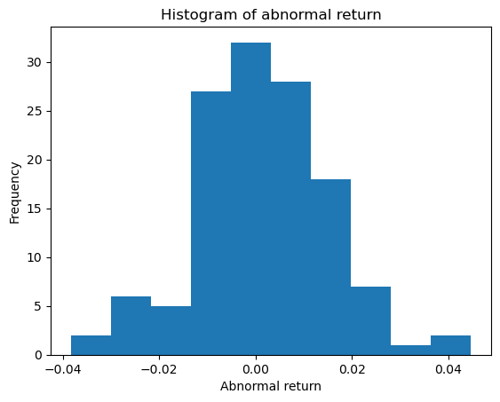

```python
import matplotlib.pyplot as plt

plt.hist(stock_return_df['Abnormal_return'])

# Add labels and title to the plot
plt.xlabel('Abnormal return')
plt.ylabel('Frequency')
plt.title('Histogram of abnormal return')

# Display the plot
plt.show()
```

```python
import pandas as pd

# Calculate descriptive statistics
stats_df = stock_return_df['Abnormal_return'].describe()

# Calculate kurtosis
kurtosis = stock_return_df['Abnormal_return'].kurtosis()

# Calculate skewness
skewness = stock_return_df['Abnormal_return'].skew()

# Add kurtosis and skewness to the statistics DataFrame
stats_df['Kurtosis'] = kurtosis
stats_df['Skewness'] = skewness

# Save the statistics DataFrame to a CSV file
#stats_df.to_csv('statistics.csv', index=False)

stats_df
```

```
count       128.000000
mean          0.001308
std           0.014095
min          -0.038359
25%          -0.006622
50%           0.000383
75%           0.010536
max           0.044718
Kurtosis      0.608183
Skewness     -0.016780
Name: Abnormal_return, dtype: float64
```